# Whale Safe Impact

Author

Emily Nazario

Published

March 11, 2025

# Voluntary Vessel Speed Reduction (VSR) Zone & Whale Safe background

## VSR data notes

San Francisco data does not include the Monterey Bay National Marine Sanctuary, which was added to the VSR program in 2023. The Whale Safe system that was launched in San Francisco was designed to give whale presence in the San Francisco portion of the VSR zones so we are reporting on them separately here for now. The Monterey Bay stats come from a different data pipeline and the offseason stats are not tracked as regularly.

### **Whale Safe System Launch Dates**

Southern California: September 17, 2020

San Francisco: September 21, 2022

### **Vessel Speed Reduction Zones**

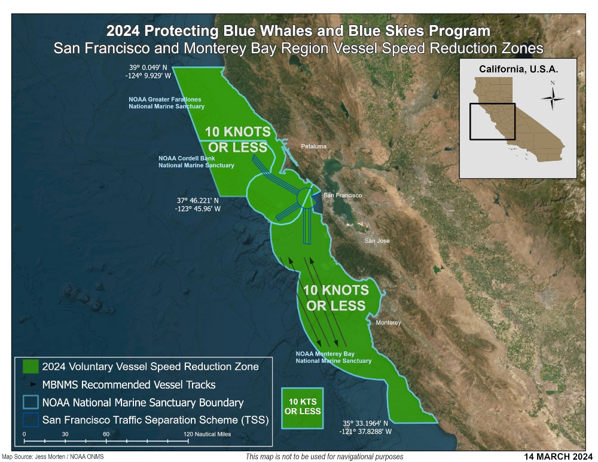

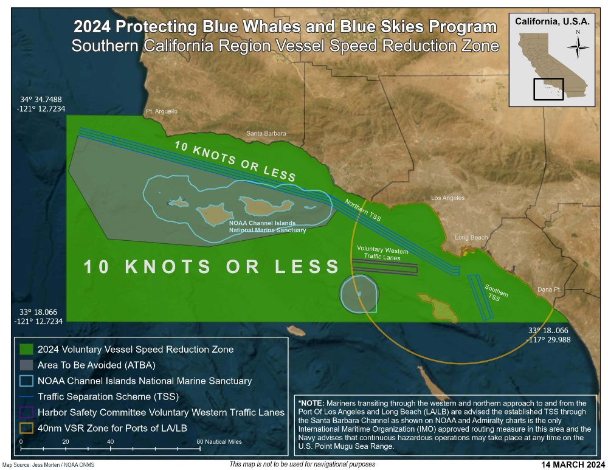

### **Vessel Speed Reduction Season Dates:**

Southern California:

- June 4 - December 31, 2018:
- May 15 - December 15, 2019
- May 15 - December 15, 2020
- May 15 - December 15, 2021
- May 1 - December 15, 2022
- May 1 - December 15, 2023
- May 1 , 2024 - January 15, 2025

San Francisco

- May 1 - November 15, 2019
- May 1 - November 15, 2020
- May 1 - November 15, 2021
- May 1 - December 15, 2022
- May 1 - December 15, 2023
- May 1 , 2024 - January 15, 2025

## WPR data notes

Blue whale model data might have been retroactively filled in after periods where the server was down. We don’t have this tracked in our data so there may be days where the Whale Presence Rating didn’t take the blue whale model value into account.

Each species has a threshold for each data stream see [Methodology](https://whalesafe.com/methodology/) for what is considered low-high (0-1). The Whale Presence Rating considers the highest rating of any of the data streams over 5 days. Two species need to have a *high* rating in order for the overall Whale Presence Rating to be ‘Very High’.

# Vessel compliance/cooperation level

## Cooperation time series w.r.t. VSR status

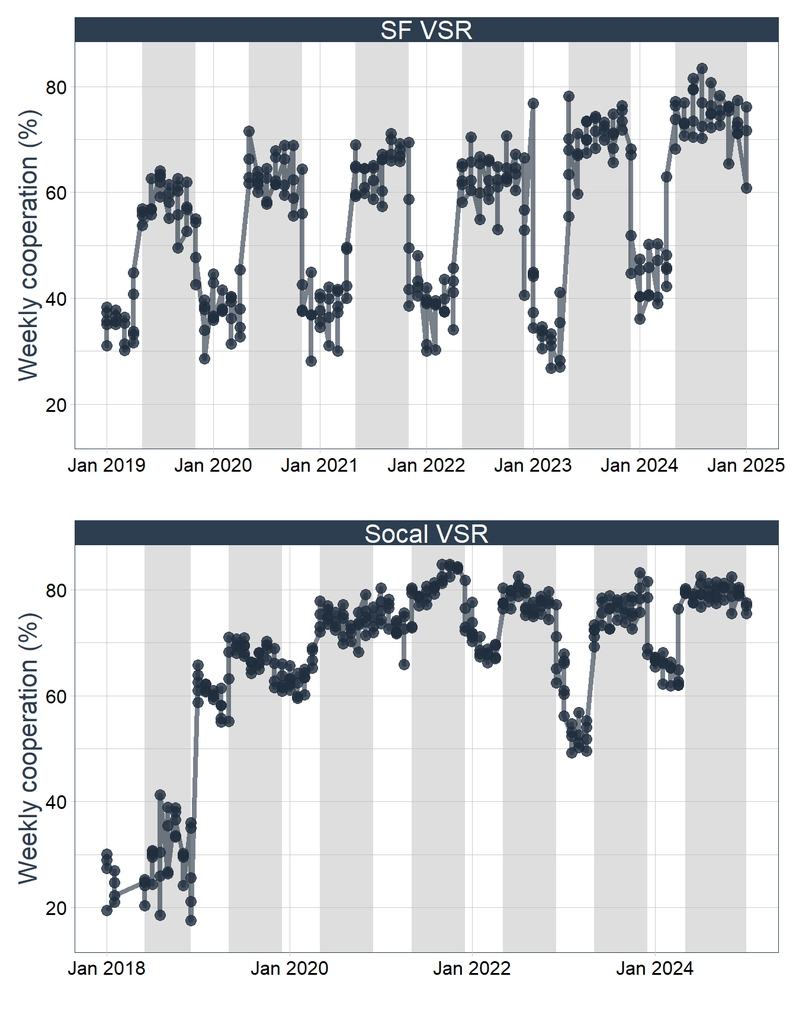

## Cooperation table: Zone x Ship category

Table displaying % cooperation grouped by region and ship category. Values in the active and inactive columns represent cooperation by VSR status, and the final column represents the change in cooperation between periods when the VSR is active vs. inactive.

| Ship category | VSR active cooperation (%) | VSR inactive cooperation (%) | Change (%) |
| --- | --- | --- | --- |
| **Monterey Bay** |  |  |  |
| bulk | 56.41516 | NA | NA |
| container | 71.99507 | NA | NA |
| fishing | 79.73571 | NA | NA |
| general cargo | 39.58673 | NA | NA |
| other industry | 60.00006 | NA | NA |
| passenger | 48.09752 | NA | NA |
| pleasure | 24.63185 | NA | NA |
| research | 76.55128 | NA | NA |
| ro-ro | 65.13670 | NA | NA |
| tanker | 62.00351 | NA | NA |
| towing/pushing | 79.52811 | NA | NA |
| **San Francisco** |  |  |  |
| bulk | 58.13379 | 37.811502 | -20.3222859 |
| container | 67.63435 | 30.487235 | -37.1471159 |
| fishing | 25.61000 | 84.623333 | 59.0133333 |
| general cargo | 44.29325 | 36.075447 | -8.2178062 |
| other industry | 51.94873 | 56.620221 | 4.6714908 |
| passenger | 48.72211 | 18.802619 | -29.9194954 |
| pleasure | 10.21415 | 6.872143 | -3.3420035 |
| research | 64.79967 | 52.764328 | -12.0353416 |
| ro-ro | 69.32563 | 37.090640 | -32.2349914 |
| tanker | 65.69202 | 35.694435 | -29.9975856 |
| towing/pushing | 79.18797 | 74.009009 | -5.1789630 |
| **Southern California** |  |  |  |
| bulk | 70.07931 | 60.473503 | -9.6058060 |
| container | 75.66559 | 57.991820 | -17.6737659 |
| fishing | 72.28187 | 65.010526 | -7.2713487 |
| general cargo | 59.09313 | 58.628251 | -0.4648776 |
| other industry | 71.31535 | 74.017635 | 2.7022831 |
| passenger | 45.43029 | 48.072736 | 2.6424482 |
| pleasure | 39.04593 | 25.476143 | -13.5697918 |
| research | 54.37780 | 54.831314 | 0.4535181 |
| ro-ro | 75.00277 | 47.438869 | -27.5638977 |
| tanker | 79.93422 | 68.444962 | -11.4892586 |
| towing/pushing | 91.19411 | 90.767121 | -0.4269873 |

## Changes in cooperation by ship category

Monterey Bay is not included in this analysis given that no data on cooperation rates during inactive VSR seasons are available.

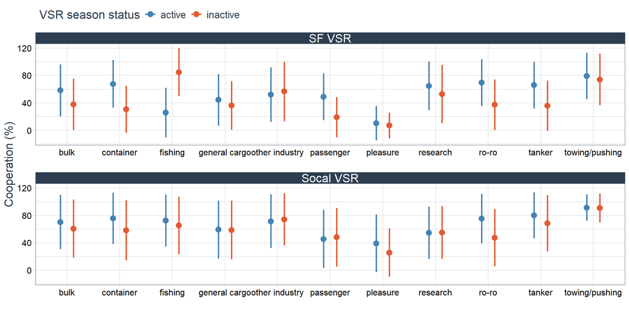

## Changes in cooperation time series

Monterey Bay is not included in this analysis given that no data on cooperation rates during inactive VSR seasons are available.

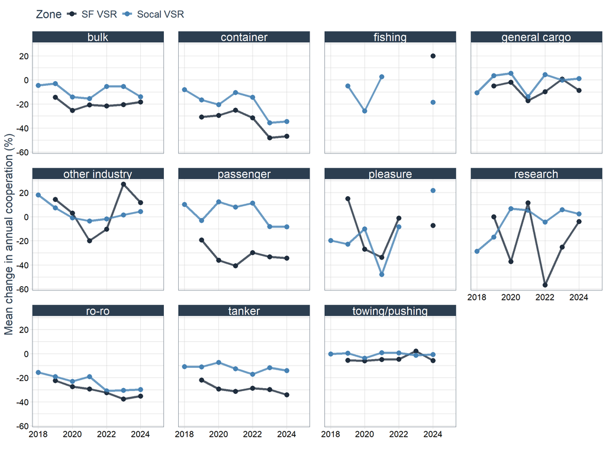

# Whale presence rating and vessel compliance

## Whale presence rating and VSR zone activity

Percent of data where the VSR zone was active vs. inactive, and within VSR status groupings, what the whale presence rating was. Monterey Bay is not included in this analysis as there is no whale presence rating data available.

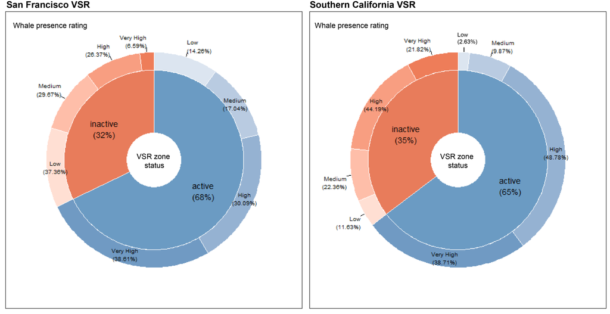

## Whale presence rating and VSR status timeseries

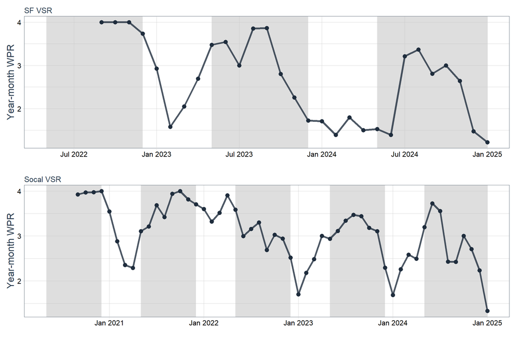

## Whale presence rating and vessel cooperation

### San Francisco

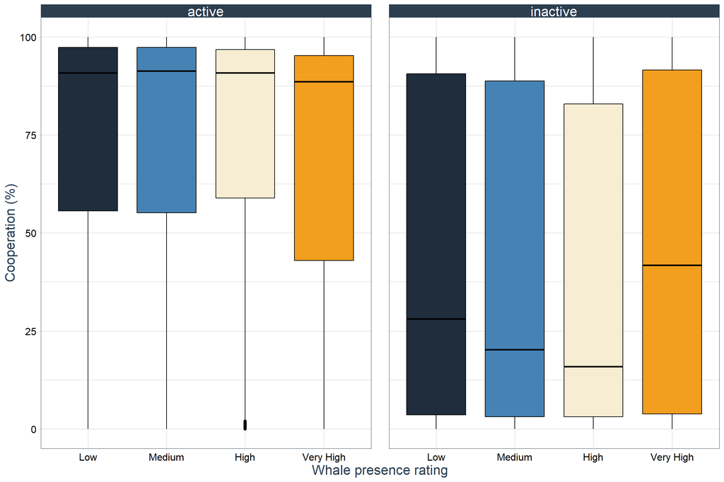

### Southern California

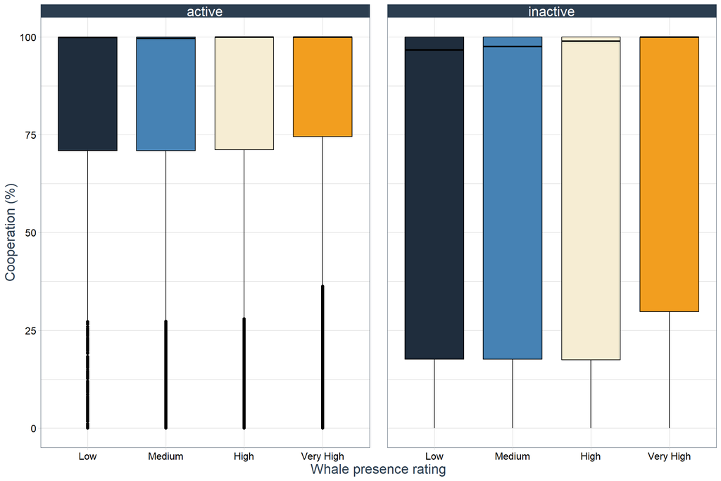

## Whale sightings data and vessel cooperation time series

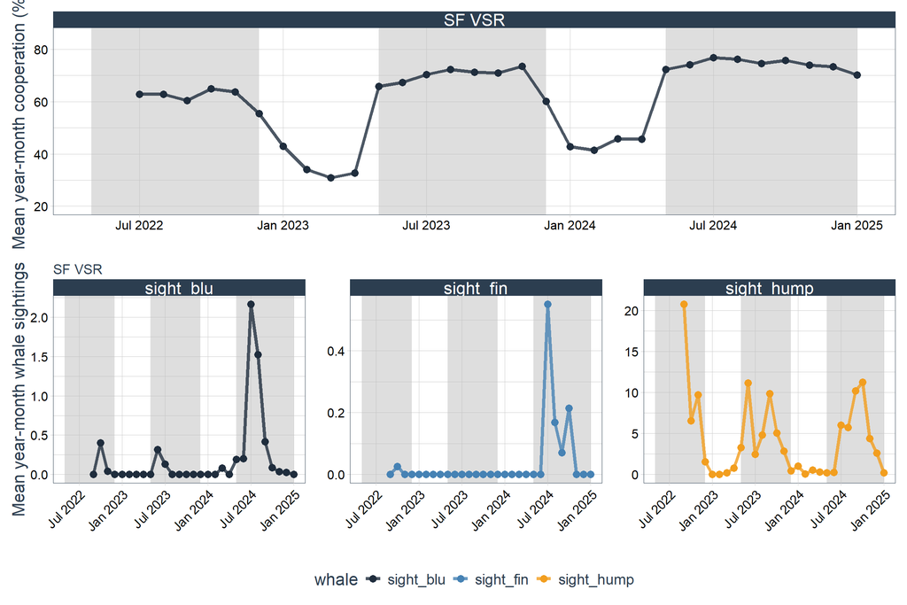

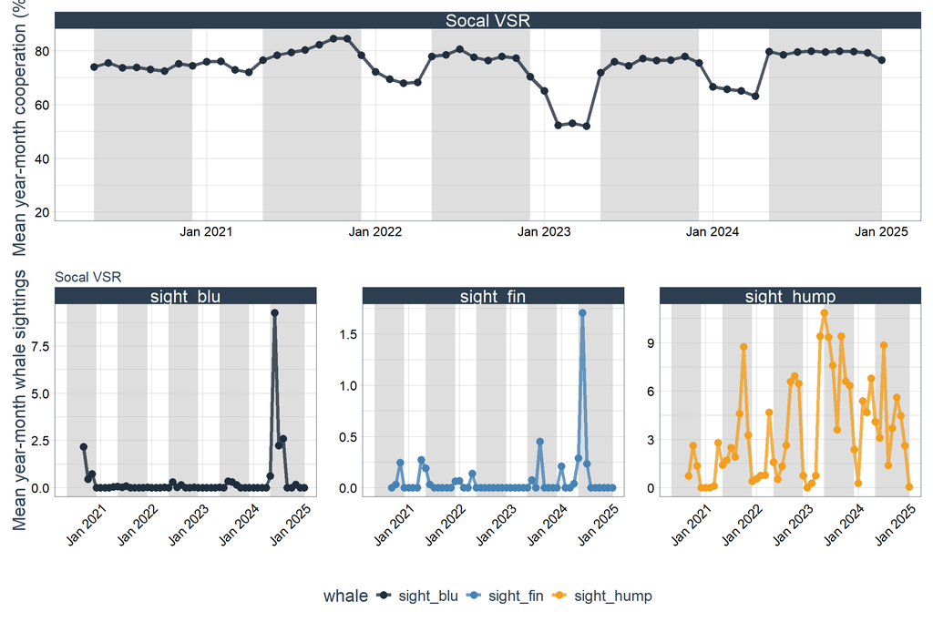

## Blue whale data streams time series

Across metrics, data points represent the year-month average for blue whales.

For the acoustics panels, year-month averages were done by assigning a “Low Rating” a 1, a “Medium Rating” a 2, a “High Rating” a 3, and “offline” an NA. Then, averages were taken of these scores, and the means were plotted as they fit across the ranges of these three bins.

### San Francisco

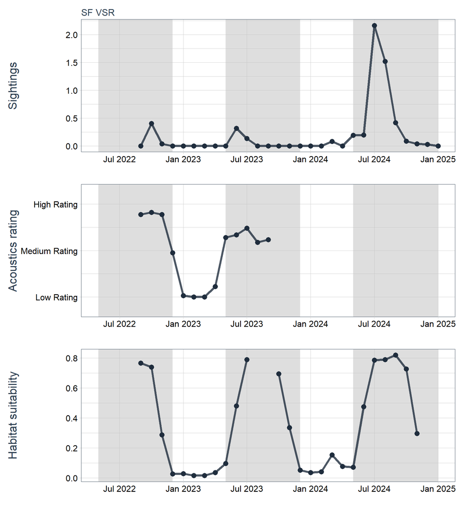

### Southern California

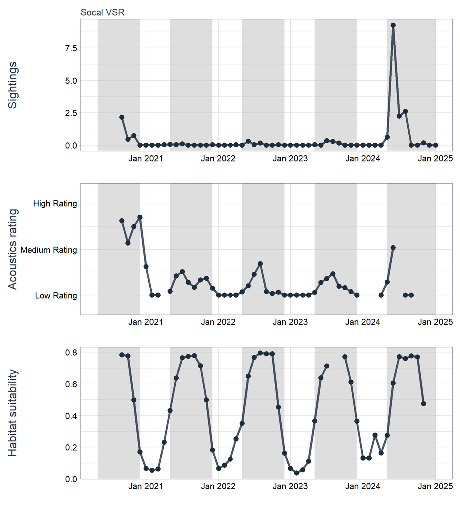

### Correlation analysis for both zones: Acoustics data and WhaleWatch predictions

#### Pearson’s

```r
sf_corr <- wpr_join %>% filter(zone == "SF VSR")
socal_corr <- wpr_join %>% filter(zone == "Socal VSR")

#SF
cor.test(sf_corr$bwmv, sf_corr$bw_ac_score)
```

```
    Pearson's product-moment correlation

data:  sf_corr$bwmv and sf_corr$bw_ac_score
t = 45.826, df = 4283, p-value < 2.2e-16
alternative hypothesis: true correlation is not equal to 0
95 percent confidence interval:
 0.5531430 0.5933383
sample estimates:
      cor
0.5735858
```

```r
#Socal
cor.test(socal_corr$bwmv, socal_corr$bw_ac_score)
```

```
    Pearson's product-moment correlation

data:  socal_corr$bwmv and socal_corr$bw_ac_score
t = 35.259, df = 80478, p-value < 2.2e-16
alternative hypothesis: true correlation is not equal to 0
95 percent confidence interval:
 0.1165298 0.1301373
sample estimates:
      cor
0.1233394
```

#### Spearman’s

```r
sf_corr <- wpr_join %>% filter(zone == "SF VSR")
socal_corr <- wpr_join %>% filter(zone == "Socal VSR")

#SF
cor.test(sf_corr$bwmv, sf_corr$bw_ac_score, method = "spearman")
```

```
    Spearman's rank correlation rho

data:  sf_corr$bwmv and sf_corr$bw_ac_score
S = 4472725166, p-value < 2.2e-16
alternative hypothesis: true rho is not equal to 0
sample estimates:
      rho
0.6589084
```

```r
#Socal
cor.test(socal_corr$bwmv, socal_corr$bw_ac_score, method = "spearman")
```

```
    Spearman's rank correlation rho

data:  socal_corr$bwmv and socal_corr$bw_ac_score
S = 7.2923e+13, p-value < 2.2e-16
alternative hypothesis: true rho is not equal to 0
sample estimates:
      rho
0.1606363
```